# lab1

## Goal of the Report:

The goal of this report is to train three linear regression models to predict the median house value. Three distinct independent variables will be used, which is median income, population, and number of households. The objective is to analyze and compare how each independent variable impacts the dependent variable and to evaluate the performance of each model in predicting house prices.

```python
import pandas as pd
import matplotlib.pyplot as plt
import seaborn as sns

from sklearn import linear_model
from sklearn.metrics import mean_squared_error, mean_absolute_error
```

## Getting the Data

Source: Downloaded from [Kaggle California Housing Prices](https://www.kaggle.com/datasets/camnugent/california-housing-prices/data)

```python
data = pd.read_csv(r'D:\2024 fall conestoga\cscn8010\lab1\archive\housing.csv')
```

## Exploratory Data Analysis (EDA)

An approach to analyzing data sets to summarize their main characteristics, often with visual methods.

```python
data.describe()
```

|  | longitude | latitude | housing_median_age | total_rooms | total_bedrooms | population | households | median_income | median_house_value |
| --- | --- | --- | --- | --- | --- | --- | --- | --- | --- |
| count | 20640.000000 | 20640.000000 | 20640.000000 | 20640.000000 | 20433.000000 | 20640.000000 | 20640.000000 | 20640.000000 | 20640.000000 |
| mean | -119.569704 | 35.631861 | 28.639486 | 2635.763081 | 537.870553 | 1425.476744 | 499.539680 | 3.870671 | 206855.816909 |
| std | 2.003532 | 2.135952 | 12.585558 | 2181.615252 | 421.385070 | 1132.462122 | 382.329753 | 1.899822 | 115395.615874 |
| min | -124.350000 | 32.540000 | 1.000000 | 2.000000 | 1.000000 | 3.000000 | 1.000000 | 0.499900 | 14999.000000 |
| 25% | -121.800000 | 33.930000 | 18.000000 | 1447.750000 | 296.000000 | 787.000000 | 280.000000 | 2.563400 | 119600.000000 |
| 50% | -118.490000 | 34.260000 | 29.000000 | 2127.000000 | 435.000000 | 1166.000000 | 409.000000 | 3.534800 | 179700.000000 |
| 75% | -118.010000 | 37.710000 | 37.000000 | 3148.000000 | 647.000000 | 1725.000000 | 605.000000 | 4.743250 | 264725.000000 |
| max | -114.310000 | 41.950000 | 52.000000 | 39320.000000 | 6445.000000 | 35682.000000 | 6082.000000 | 15.000100 | 500001.000000 |

## Seaborn scatter plots

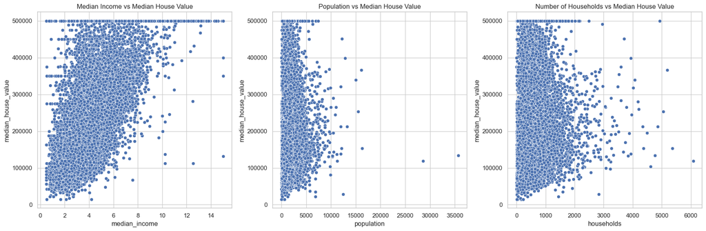

```python
x_vars = ['median_income', 'population', 'households']
y_var = 'median_house_value'


fig, axes = plt.subplots(1, 3, figsize=(18, 6))


sns.scatterplot(ax=axes[0], x='median_income', y='median_house_value', data=data)
axes[0].set_title('Median Income vs Median House Value')


sns.scatterplot(ax=axes[1], x='population', y='median_house_value', data=data)
axes[1].set_title('Population vs Median House Value')


sns.scatterplot(ax=axes[2], x='households', y='median_house_value', data=data)
axes[2].set_title('Number of Households vs Median House Value')


plt.tight_layout()
plt.show()
```

## Interpretation of the Scatter Plots:

1. Median Income vs. Median House Value: The scatter plot shows a strong positive relationship between median income and median house value. As median income increases, the median house value tends to rise.
2. Population vs. Median House Value: The plot shows a weak relationship between population and median house value. The data points are scattered, which means population size alone may not be a strong predictor.
3. Number of Households vs. Median House Value: There is a slight positive trend, but not as strong as with median income.

Insights for Linear Regression: Median Income is expected to be the strongest predictor based on the trend. Population may not provide a strong predictive ability due to its weak correlation. Number of Households might have some predictive power but not as strong as median income.

## Observations:

Median House Value: Median House Value is the dependent variable, representing the median house price in each region. Typically ranges from lower values around 15,000 to as high as 500,000 dollars. There is a noticeable upper limit at 500,000 dollars, which shows that there is a limitations in the dataset.

Median Income: It is the median income of households in each region. It shows the economic status of the area. The values range between approximately 0.5 to 15 in tens of thousands of dollars. There is a strong positive correlation with median house value.

Population: This is the total population of each region. The values vary widely, from small populations under 300 to over 35,000. The relationship with median house value is weak, this could demonstrate that population size does not strongly influence house prices.

## Linear regressions for each independent variable

```python
import statsmodels.api as sm

y = data['median_house_value']

X_income = data['median_income']
X_income = sm.add_constant(X_income)
model_income = sm.OLS(y, X_income).fit()


X_population = data['population']
X_population = sm.add_constant(X_population)
model_population = sm.OLS(y, X_population).fit()


X_households = data['households']
X_households = sm.add_constant(X_households)
model_households = sm.OLS(y, X_households).fit()


print("Regression 1: Median House Value vs. Median Income")
print(model_income.summary())

print("\nRegression 2: Median House Value vs. Population")
print(model_population.summary())

print("\nRegression 3: Median House Value vs. Number of Households")
print(model_households.summary())
```

```
Regression 1: Median House Value vs. Median Income
                            OLS Regression Results
==============================================================================
Dep. Variable:     median_house_value   R-squared:                       0.473
Model:                            OLS   Adj. R-squared:                  0.473
Method:                 Least Squares   F-statistic:                 1.856e+04
Date:                Tue, 24 Sep 2024   Prob (F-statistic):               0.00
Time:                        00:08:45   Log-Likelihood:            -2.6325e+05
No. Observations:               20640   AIC:                         5.265e+05
Df Residuals:                   20638   BIC:                         5.265e+05
Df Model:                           1
Covariance Type:            nonrobust
=================================================================================
                    coef    std err          t      P>|t|      [0.025      0.975]
---------------------------------------------------------------------------------
const          4.509e+04   1322.872     34.082      0.000    4.25e+04    4.77e+04
median_income  4.179e+04    306.806    136.223      0.000    4.12e+04    4.24e+04
==============================================================================
Omnibus:                     4245.795   Durbin-Watson:                   0.655
Prob(Omnibus):                  0.000   Jarque-Bera (JB):             9273.446
Skew:                           1.191   Prob(JB):                         0.00
Kurtosis:                       5.260   Cond. No.                         10.2
==============================================================================

Notes:
[1] Standard Errors assume that the covariance matrix of the errors is correctly specified.

Regression 2: Median House Value vs. Population
                            OLS Regression Results
==============================================================================
Dep. Variable:     median_house_value   R-squared:                       0.001
Model:                            OLS   Adj. R-squared:                  0.001
Method:                 Least Squares   F-statistic:                     12.55
Date:                Tue, 24 Sep 2024   Prob (F-statistic):           0.000398
Time:                        00:08:45   Log-Likelihood:            -2.6986e+05
No. Observations:               20640   AIC:                         5.397e+05
Df Residuals:                   20638   BIC:                         5.397e+05
Df Model:                           1
Covariance Type:            nonrobust
==============================================================================
```

[output cut: 29 more lines]

```
                 coef    std err          t      P>|t|      [0.025      0.975]
------------------------------------------------------------------------------
const       1.969e+05   1318.748    149.330      0.000    1.94e+05       2e+05
households    19.8728      2.096      9.479      0.000      15.764      23.982
==============================================================================
Omnibus:                     2520.280   Durbin-Watson:                   0.322
Prob(Omnibus):                  0.000   Jarque-Bera (JB):             3541.913
Skew:                           0.998   Prob(JB):                         0.00
Kurtosis:                       3.370   Cond. No.                     1.04e+03
==============================================================================

Notes:
[1] Standard Errors assume that the covariance matrix of the errors is correctly specified.
[2] The condition number is large, 1.04e+03. This might indicate that there are
strong multicollinearity or other numerical problems.
```

## Regression model

```python
from sklearn.linear_model import LinearRegression
from sklearn.metrics import mean_squared_error, mean_absolute_error
from IPython.display import display  # Use IPython display for Jupyter


X_income = data[['median_income']]
X_population = data[['population']]
X_households = data[['households']]
y = data['median_house_value']

results = {'Model': [], 'Intercept': [], 'Slope': [], 'MSE': [], 'MAE': []}


def perform_regression(X, y, model_name):
    model = LinearRegression()
    model.fit(X, y)


    y_pred = model.predict(X)


    mse = mean_squared_error(y, y_pred)
    mae = mean_absolute_error(y, y_pred)


    results['Model'].append(model_name)
    results['Intercept'].append(model.intercept_)
    results['Slope'].append(model.coef_[0])
    results['MSE'].append(mse)
    results['MAE'].append(mae)


perform_regression(X_income, y, 'Median Income vs House Value')
perform_regression(X_population, y, 'Population vs House Value')
perform_regression(X_households, y, 'Households vs House Value')


results_df = pd.DataFrame(results)


display(results_df)
```

|  | Model | Intercept | Slope | MSE | MAE |
| --- | --- | --- | --- | --- | --- |
| 0 | Median Income vs House Value | 45085.576703 | 41793.849202 | 7.011312e+09 | 62625.933791 |
| 1 | Population vs House Value | 210436.262076 | -2.511753 | 1.330741e+10 | 91153.820095 |
| 2 | Households vs House Value | 196928.577162 | 19.872775 | 1.325778e+10 | 90802.743243 |

## The resulting linear regression models

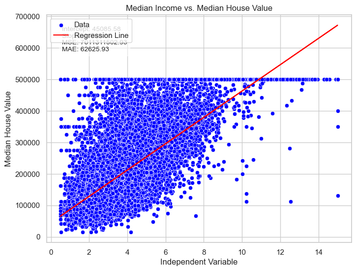

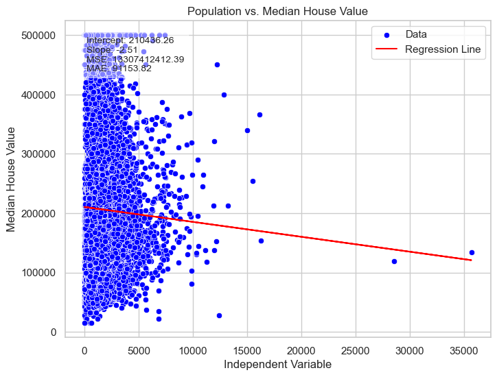

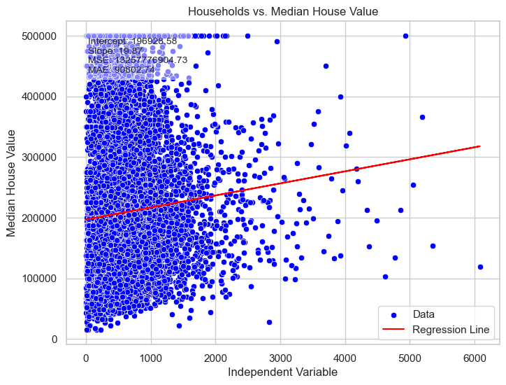

```python
# Import necessary libraries
import matplotlib.pyplot as plt
import seaborn as sns
import statsmodels.api as sm

# Function to plot scatter plot with regression line and metrics
def plot_regression(X, y, model, model_name, mse, mae, intercept, slope):
    plt.figure(figsize=(8, 6))

    # Scatter plot
    sns.scatterplot(x=X.squeeze(), y=y, label='Data', color='blue')

    # Add constant to X for prediction (since the model was fitted with a constant)
    X_with_const = sm.add_constant(X)

    # Plot regression line
    plt.plot(X, model.predict(X_with_const), color='red', label=f'Regression Line')

    # Title and labels
    plt.title(f'{model_name}')
    plt.xlabel('Independent Variable')
    plt.ylabel('Median House Value')

    # Add text box with line parameters and error metrics
    textstr = f'Intercept: {intercept:.2f}\nSlope: {slope:.2f}\nMSE: {mse:.2f}\nMAE: {mae:.2f}'
    plt.gca().text(0.05, 0.95, textstr, transform=plt.gca().transAxes, fontsize=10,
                   verticalalignment='top', bbox=dict(facecolor='white', alpha=0.5))

    # Show the plot
    plt.legend()
    plt.show()

# Plot for Median Income vs. House Value
plot_regression(X_income, y, model_income, 'Median Income vs. Median House Value',
                mse=results_df.loc[0, 'MSE'], mae=results_df.loc[0, 'MAE'],
                intercept=results_df.loc[0, 'Intercept'], slope=results_df.loc[0, 'Slope'])

# Plot for Population vs. House Value
plot_regression(X_population, y, model_population, 'Population vs. Median House Value',
                mse=results_df.loc[1, 'MSE'], mae=results_df.loc[1, 'MAE'],
                intercept=results_df.loc[1, 'Intercept'], slope=results_df.loc[1, 'Slope'])

# Plot for Households vs. House Value
plot_regression(X_households, y, model_households, 'Households vs. Median House Value',
                mse=results_df.loc[2, 'MSE'], mae=results_df.loc[2, 'MAE'],
                intercept=results_df.loc[2, 'Intercept'], slope=results_df.loc[2, 'Slope'])
```

## Summary

Median Income vs. Median House Value: This model had the best fit, with the lowest MSE and MAE. The strong linear relationship shows that with median income increases, house prices also increase. Median income is a predictor of house prices, showing that areas with higher income levels tend to have higher house values.

Population vs. Median House Value: This model had the weakest fit, with high error values. There is no clear relationship between population size and house prices. Population size alone does not seem to have much impact on house prices.

Number of Households vs. Median House Value: The model showed a slight positive relationship between the number of households and house prices. The number of households has some influence on house prices but is not as strong as income.